# Gurjus_Singh_Module 7_Mini Programming Assignment_Implement Dijkstra's Algorithm

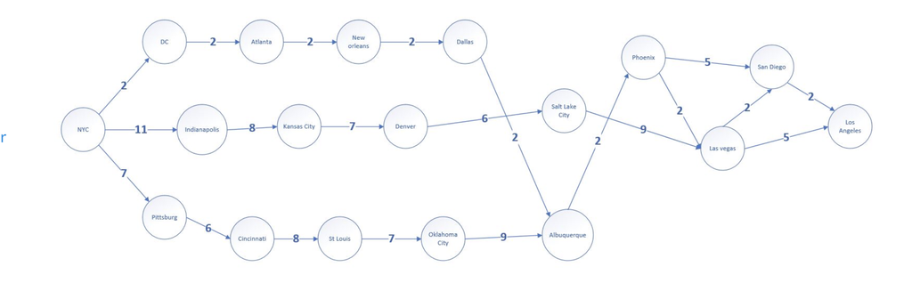

```python
import numpy as np
import time
import matplotlib.pyplot as plt
```

```python
#First make the graph
graph = {}
#adding nodes and neighbors with edges

#FIRST NEW YORK
graph["NYC"] = {}
graph["NYC"]["DC"] = 2
graph["NYC"]["Pittsburg"] = 7
graph["NYC"]["Indianapolis"] = 11

#DC
graph["DC"] = {}
graph["DC"]["Atlanta"] = 2

#Indianapolis
graph["Indianapolis"] = {}
graph["Indianapolis"]["Kansas City"] = 8

#Pittsburg
graph["Pittsburg"] = {}
graph["Pittsburg"]["Cincinnati"] = 6

#Atlanta
graph["Atlanta"] = {}
graph["Atlanta"]["New Orleans"] = 2

#Kansas City
graph["Kansas City"] = {}
graph["Kansas City"]["Denver"] = 7

#Cincinnati
graph["Cincinnati"] = {}
graph["Cincinnati"]["St Louis"] = 8

#New Orleans
graph["New Orleans"] = {}
graph["New Orleans"]["Dallas"] = 2

#Denver
graph["Denver"] = {}
graph["Denver"]["Salt Lake City"] = 6

#St Louis
graph["St Louis"] = {}
graph["St Louis"]["Oklahoma City"] = 7

#Dallas
graph["Dallas"] = {}
graph["Dallas"]["Albuquerque"] = 2

#Salt Lake City
graph["Salt Lake City"] = {}
graph["Salt Lake City"]["Las Vegas"] = 9

#Oklahoma City
graph["Oklahoma City"] = {}
graph["Oklahoma City"]["Albuquerque"] = 9

#Albuquerque
graph["Albuquerque"] = {}
graph["Albuquerque"]["Phoenix"] = 2

#Phoenix
graph["Phoenix"] = {}
graph["Phoenix"]["Las Vegas"] = 2
graph["Phoenix"]["San Diego"] = 5

#Las Vegas
graph["Las Vegas"] = {}
graph["Las Vegas"]["San Diego"] = 2
graph["Las Vegas"]["Los Angeles"] = 5

#San Diego
graph["San Diego"] = {}
graph["San Diego"]["Los Angeles"] = 2

#Los Angeles
graph["Los Angeles"] = {}
```

```python
infinity = float("inf")
```

```python
#figure out cost
costs = {}
costs["NYC"] = 0
costs["DC"] = 2
costs["Indianapolis"] = 11
costs["Pittsburg"] = 7
costs["Phoenix"] = infinity
costs["Los Angeles"] = infinity
costs["San Diego"] = infinity
costs["Albuquerque"] = infinity
costs["Oklahoma City"] = infinity
costs["Salt Lake City"] = infinity
costs["Dallas"] = infinity
costs["St Louis"] = infinity
costs["Denver"] = infinity
costs["Atlanta"] = infinity
costs["New Orleans"] = infinity
costs["Kansas City"] = infinity
costs["Cincinnati"] = infinity
costs["Las Vegas"] = infinity
```

```python
parents = {}
parents["NYC"] = None
parents["DC"] = "NYC"
parents["Indianapolis"] = "NYC"
parents["Pittsburg"] = "NYC"
parents["Phoenix"] = None
parents["Los Angeles"] = None
parents["San Diego"] = None
parents["Albuquerque"] = None
parents["Oklahoma City"] = None
parents["Salt Lake City"] = None
parents["Dallas"] = None
parents["St Louis"] = None
parents["Denver"] = None
parents["Atlanta"] = None
parents["New Orleans"] = None
parents["Cincinnati"] = None
parents["Las Vegas"] = None
parents["Las Vegas"] = None
parents["San Diego"] = None

processed = []
```

```python
def print_path(l):
    for i in l:
        if i == l[len(l)-1]:
            print(i)
        else:
            print(f"{i} --> ", end="")
```

```python
def find_lowest_cost_node(costs):
    lowest_cost = float("inf")
    lowest_cost_node = None
    # Go through each node.
    for node in costs:
        cost = costs[node]
        # If it's the lowest cost so far and hasn't been processed yet...
        if cost < lowest_cost and node not in processed:
            # ... set it as the new lowest-cost node.
            lowest_cost = cost
            lowest_cost_node = node
    return lowest_cost_node

def dikjstra(dest):
    # Find the lowest-cost node that you haven't processed yet.
    node = find_lowest_cost_node(costs)
    # If you've processed all the nodes, this while loop is done.
    while node is not None and node != dest:
        cost = costs[node]
        # Go through all the neighbors of this node.
        neighbors = graph[node]
        for n in neighbors.keys():
            new_cost = cost + neighbors[n]
            # If it's cheaper to get to this neighbor by going through this node...
            if costs[n] > new_cost:
                # ... update the cost for this node.
                costs[n] = new_cost
                # This node becomes the new parent for this neighbor.
                parents[n] = node
        # Mark the node as processed.
        processed.append(node)
        # Find the next node to process, and loop.
        node = find_lowest_cost_node(costs)
```

```python
#make graohs

graph2 = {}
graph2["Level 1"] = ["NYC"]
graph2["NYC"] = ["Pittsburg","Indianapolis","DC"]
graph2["DC"] = ["Atlanta"]
graph2["Indianapolis"] = ["Kansas City"]
graph2["Kansas City"] = ["Denver"]
graph2["Denver"] = ["Salt Lake City"]
graph2["Salt Lake City"] = ["Las Vegas"]
graph2["Las Vegas"] = ["San Diego", "Los Angeles"]
graph2["Pittsburg"] = ["Cincinnati"]
graph2["Atlanta"] = ["New Orleans"]
graph2["Cincinnati"] = ["St Louis"]
graph2["New Orleans"] = ["Dallas"]
graph2["St Louis"] = ["Oklahoma City"]
graph2["Oklahoma City"] = ["Albuquerque"]
graph2["Dallas"] = ["Albuquerque"]
graph2["Albuquerque"] = ["Phoenix"]
graph2["Phoenix"] = ["Las Vegas", "San Diego"]
graph2["San Diego"] = ["Los Angeles"]
graph2["Los Angeles"] = []



def bfs_search(dest):
    search_queue = deque()
    #changed from name to level 1 so it added the level 1 first to the queue before adding it's connections from before
    search_queue += graph2["Level 1"]
    # This array is how you keep track of which city you've searched before.
    searched = []
    while search_queue:
        print(search_queue)
        city = search_queue.popleft()
        # Only search this city if you haven't already searched them.
        if city not in searched:
            #when the city in the graph is found make sure it matches the name wanted
            if  city == dest:
                return True
            else:
                search_queue += graph2[city]
                # Marks this person as searched
                searched.append(city)
    return False
```

# PART 1

```python
a = time.perf_counter()
bfs_search("Los Angeles")
b = time.perf_counter()
getbfstime = (b - a)*1000
getbfstime
```

```
deque(['NYC'])
deque(['Pittsburg', 'Indianapolis', 'DC'])
deque(['Indianapolis', 'DC', 'Cincinnati'])
deque(['DC', 'Cincinnati', 'Kansas City'])
deque(['Cincinnati', 'Kansas City', 'Atlanta'])
deque(['Kansas City', 'Atlanta', 'St Louis'])
deque(['Atlanta', 'St Louis', 'Denver'])
deque(['St Louis', 'Denver', 'New Orleans'])
deque(['Denver', 'New Orleans', 'Oklahoma City'])
deque(['New Orleans', 'Oklahoma City', 'Salt Lake City'])
deque(['Oklahoma City', 'Salt Lake City', 'Dallas'])
deque(['Salt Lake City', 'Dallas', 'Albuquerque'])
deque(['Dallas', 'Albuquerque', 'Las Vegas'])
deque(['Albuquerque', 'Las Vegas', 'Albuquerque'])
deque(['Las Vegas', 'Albuquerque', 'Phoenix'])
deque(['Albuquerque', 'Phoenix', 'San Diego', 'Los Angeles'])
deque(['Phoenix', 'San Diego', 'Los Angeles'])
deque(['San Diego', 'Los Angeles', 'Las Vegas', 'San Diego'])
deque(['Los Angeles', 'Las Vegas', 'San Diego', 'Los Angeles'])
```

```
0.9171140009129886
```

# PART 2

```python
#Path Breadtth Search finds that path with least number of edges is this route
bfsstops = ['NYC', 'Indianapolis', 'Kansas City', 'Denver', 'Salt Lake City' , 'Las Vegas', 'Los Angeles']
#print out path
print_path(bfsstops)
bfstime = sum([11, 8, 7, 6, 9, 5])
#get number of hours by adding up weights
print(str(bfstime) + ' hrs')

#get number of stops by figuring out lengtb
bfsnode = len(bfsstops)
#display stops
str(bfsnode) + ' stops'
```

```
NYC --> Indianapolis --> Kansas City --> Denver --> Salt Lake City --> Las Vegas --> Los Angeles
46 hrs
```

```
'7 stops'
```

# PART 3

```python
a = time.perf_counter()
dikjstra("Los Angeles")
b = time.perf_counter()
getdkjtime =(b - a)*1000
dkjtime = costs['Los Angeles']
print(getdkjtime)
str(dkjtime) + ' hrs'
```

```
0.057976998505182564
```

```
'18 hrs'
```

# PART 4

```python
#get nodes form parents graph
def print_dfs_search():
    path = []
    node = "Los Angeles"
    while parents[node]:
        path.insert(0, node)
        node = parents[node]
        if node == "NYC":
            path.insert(0, node)
    return path

#get length of path
dkjnode = len(print_dfs_search())
#print it
print_path(print_dfs_search())
#display stops
str(dkjnode) + ' stops'
```

```
NYC --> DC --> Atlanta --> New Orleans --> Dallas --> Albuquerque --> Phoenix --> Las Vegas --> San Diego --> Los Angeles
```

```
'10 stops'
```

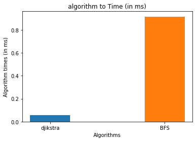

```python
width = 0.35  # the width of the bars
fig, ax = plt.subplots()
bar1 = ax.bar(['djikstra'],getdkjtime, width, label='Dijkstra search route', align = 'center')
bar2 = ax.bar(['BFS'],getbfstime, width, label='Breadth-First search route')
ax.set_ylabel('Algorithm times (in ms)')
ax.set_xlabel("Algorithms")
ax.set_title('algorithm to Time (in ms)')
```

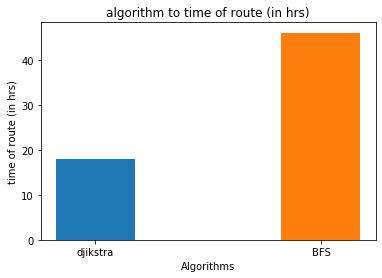

```python
width = 0.35  # the width of the bars
fig, ax = plt.subplots()
bar1 = ax.bar(['djikstra'],dkjtime, width, label='Dijkstra search route', align = 'center')
bar2 = ax.bar(['BFS'],bfstime, width, label='Breadth-First search route')
ax.set_ylabel('time of route (in hrs)')
ax.set_xlabel("Algorithms")
ax.set_title('algorithm to time of route (in hrs)')
```

[figure not shown]

```python
width = 0.35  # the width of the bars
fig, ax = plt.subplots()
bar1 = ax.bar(['djikstra'],dkjnode, width, label='Dijkstra search route', align = 'center')
bar2 = ax.bar(['BFS'],bfsnode, width, label='Breadth-First search route')
ax.set_ylabel('stops made')
ax.set_xlabel("Algorithms")
ax.set_title('algorithm to time of route (in hrs)')
```

In this programming exericise we examine the shortest path using Breadth first search and Dijkstra's Algorithm. We first made a graph with weights for the Dijkstra's algorithm and made a graph like in the last programming assignment without the weights for Breadth First Seach.

From comparing the algorithms, the number of stops made is greater for Dijkstra's which has a total of 10 stops while Breadth First Search has 7 stops which is less. The path that Djikstra's algorithm is going from NYC --> DC --> Atlanta route, while Breadth First Search takes the NYC-->Indianapolis--->Denver route. It takes less hours to travel from New York City to Los Angeles which is 18 hours as this is the goal of Dijkstra's algorithm, while Breadth First Search takes 46 hours because it does not look at the weights but instead uses the path with the least amount of edges. In terms of complexity Dijkstra's algorithm takes less time since it does not have to look through all the nodes and just makes sure it looks through lowest cost nodes.

The algorthm complexity is O(E logV), because you are reducing the number of edges to look through by going to through the edges with less weights, but can get worst when you have graph where all nodes are not connected. In the case of Breadth First Search, it is going through all the nodes and edges and has a time of O(V + E).

Source: https://stackoverflow.com/questions/26547816/understanding-time-complexity-calculation-for-dijkstra-algorithm